# final_exam

Rick Shemanski

March 17, 2016

Cancellations vs Months by origin

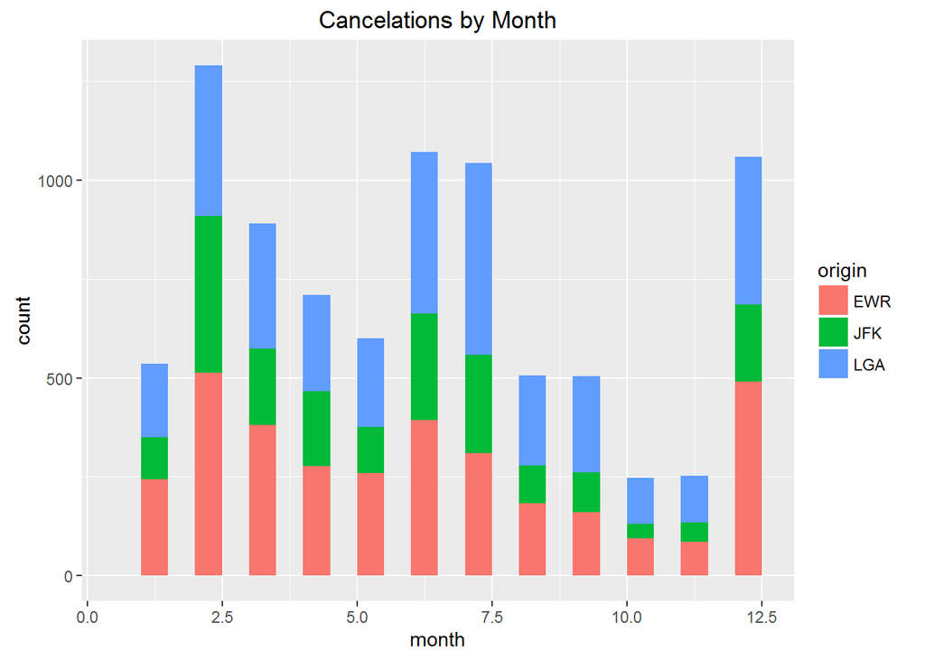

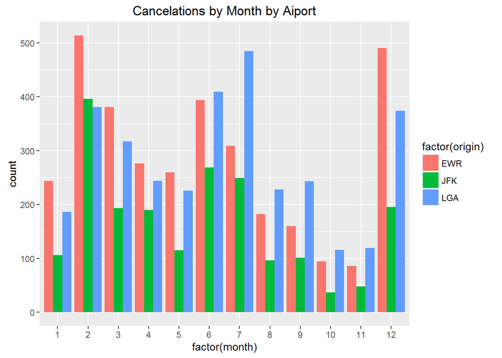

The above plots show the cancellations by month for NYC airport. This information can help travel choose a originating airport based off what time of year they are traveling. These numbers are in total cancellations, not as a cancellation/total flight ratio. In the future a ratio will be used to ensure that origins with greater total flights are not misrepresented.

Cancellations vs Destination

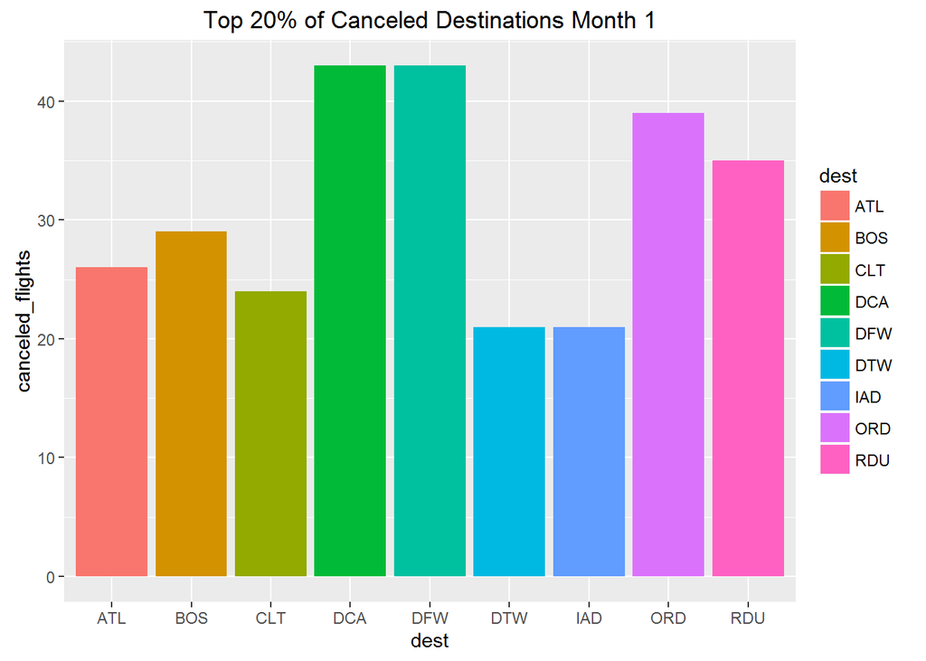

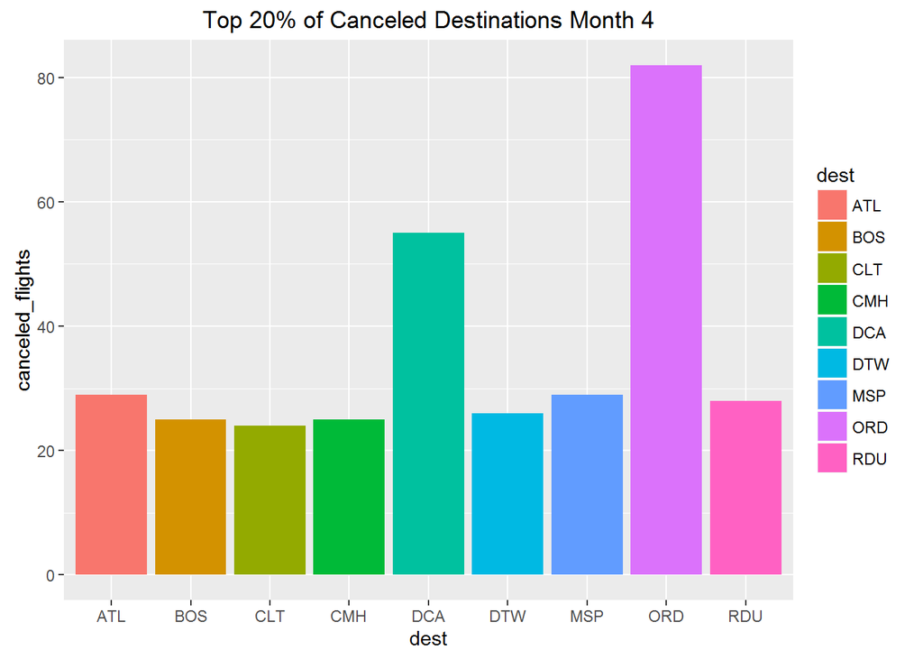

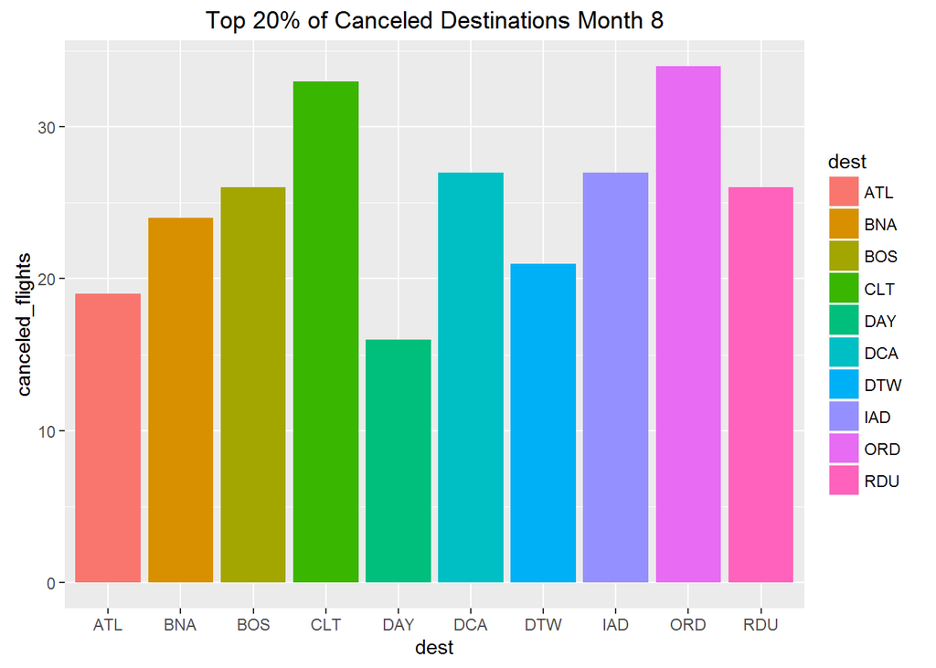

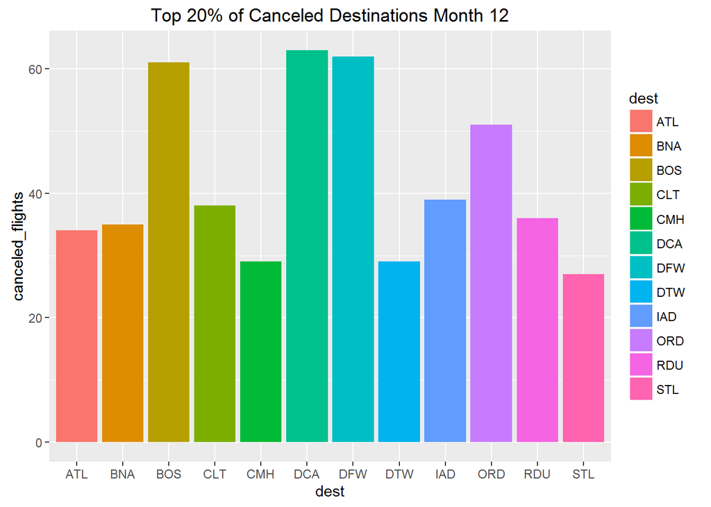

Below we examined the cancellations for each destination for a specific month. We compared the cancellations at a specific destination to all other destinations’ cancellations. We then determined which destinations were the Top 20% Most Canceled Destinations for a specific month. In the future we also need to use a cancellation ratio, so to account for larger airports (ATL, DALLAS, etc…) having a greater number of cancellations.

This section I feel would be very different than anyone else. Code starts on RMD135

```
## [1] 3322
```

Delays vs Time

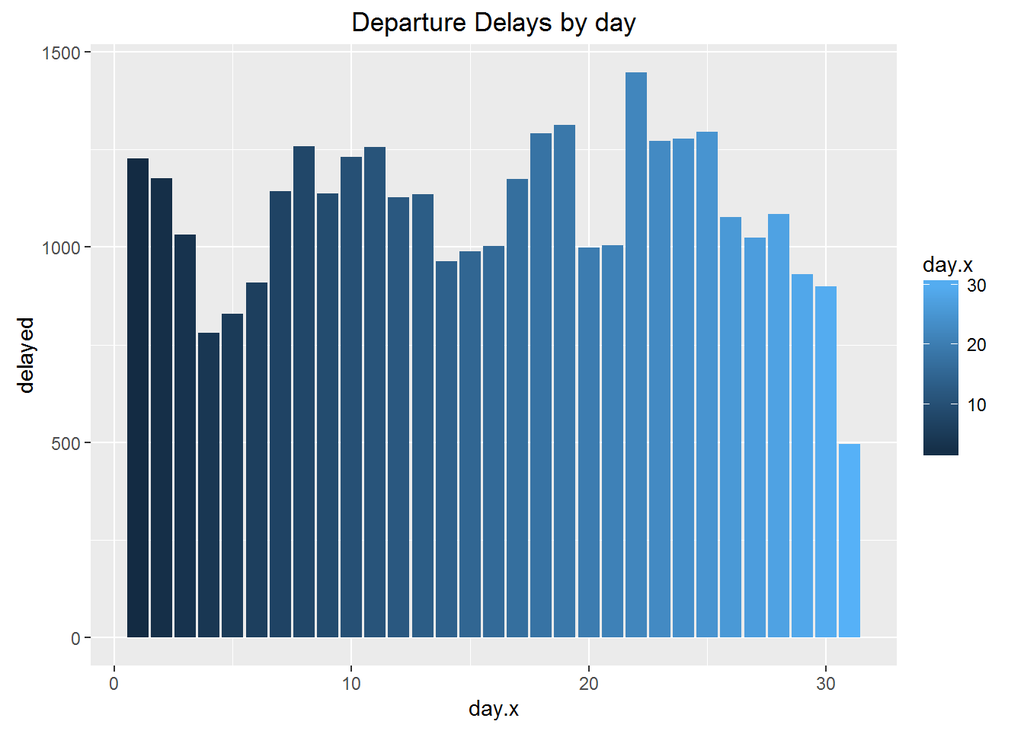

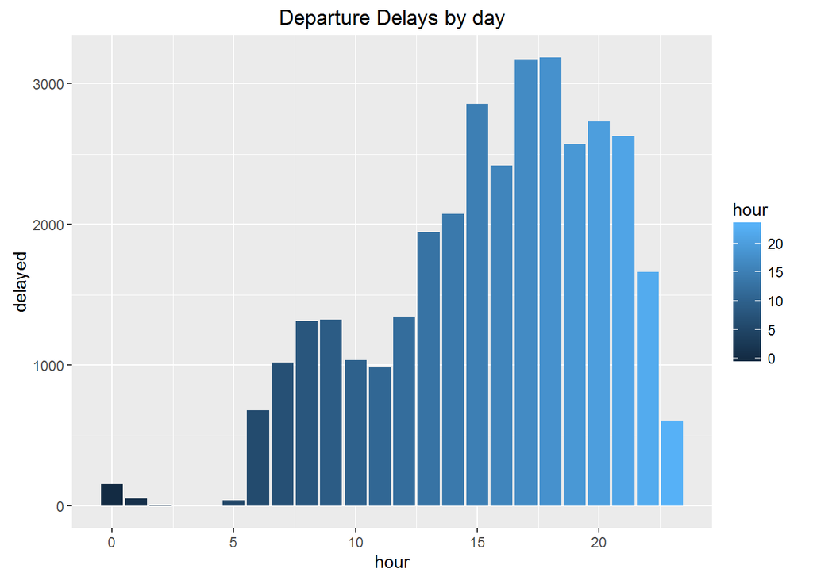

In the above plots we can see the number of delayed flights as function of time. There seems to be no strong correlation between if a flight will be delayed based upon how late the departure is into the month.

Delays vs Plane Characteristics

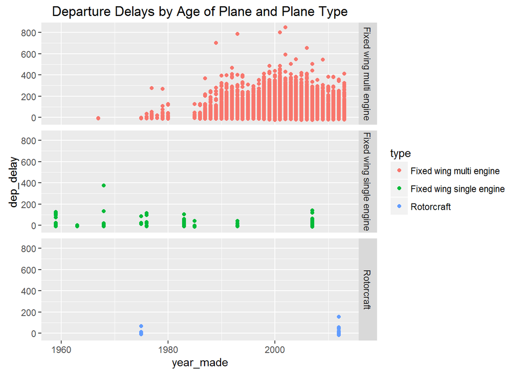

Delays vs Weather

Wind vs Delays

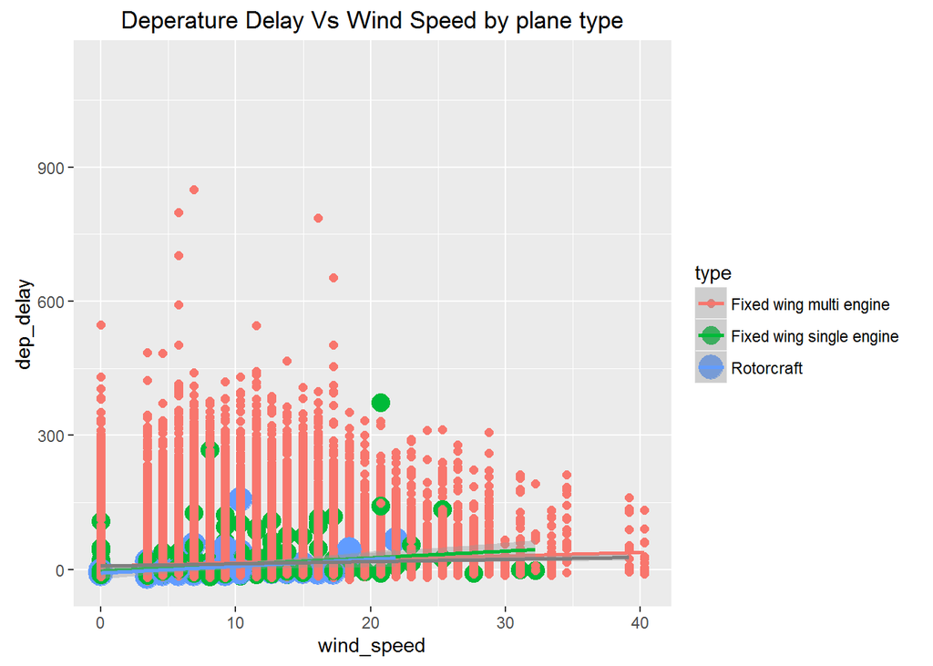

In the above plot we can see how wind-speed effects departure delays by plane type. We might think that newer planes would be able to operate in higher wind-speeds, but there does not seem to be a strong indication. A linear regression line for each plane type shows how wind-speed affects departure delays.

Visibility vs Cancelled Flights

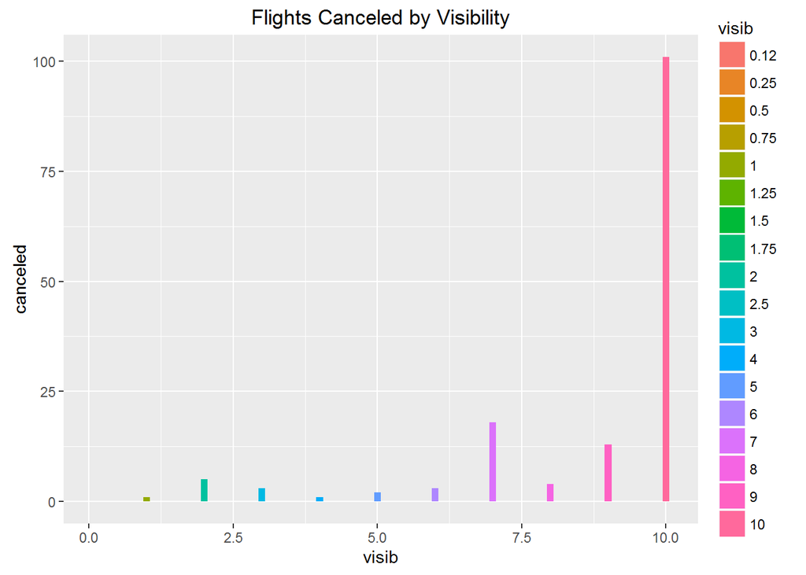